# Graphing the data

Asmus Hylkjaer

created 07/12/2022, updated date: 08 January, 2023

##Graphing

```r
library(tidyverse)
library(readxl)
library(cowplot)
library(ggplot2)
library(here)
```

```r
Heritage_list_graph_data2 <- read_excel("data/inscribtion_data.xlsx")
```

## Inspect the data

```r
head(Heritage_list_graph_data2)
```

```
## # A tibble: 6 × 39
##    year inscri…¹ cumul…² Cultu…³ Natur…⁴ Mixed…⁵ Total…⁶ cumul…⁷ proce…⁸ Cultu…⁹
##   <dbl>    <dbl>   <dbl>   <dbl>   <dbl>   <dbl>   <dbl>   <dbl>   <dbl>   <dbl>
## 1  1978       12      12       5       2       0       7       7    58.3       0
## 2  1979       45      57      18       6       1      25      32    55.6       4
## 3  1980       27      84       8       2       0      10      42    37.0       3
## 4  1981       26     110       9       2       0      11      53    42.3       2
## 5  1982       24     134       3       0       0       3      56    12.5       3
## 6  1983       29     163      13       5       0      18      74    62.1       4
## # … with 29 more variables: Natural_AsP <dbl>, Mixed_AsP <dbl>,
## #   Total_AsP <dbl>, `cumulative _AsP` <dbl>, procentage_year_AsP <dbl>,
## #   Cultural_LA <dbl>, Natural_LA <dbl>, Mixed_LA <dbl>, Total_LA <dbl>,
## #   `cumulative _LA` <dbl>, procentage_year_LA <dbl>, Cultural_AS <dbl>,
## #   Natural_AS <dbl>, Mixed_AS <dbl>, Total_AS <dbl>, `cumulative _AS` <dbl>,
## #   procentage_year_AS <dbl>, Cultural_AF <dbl>, Natural_AF <dbl>,
## #   Mixed_AF <dbl>, Total_AF <dbl>, `cumulative _AF` <dbl>, …
```

## Let’s how many percentage are added a year pr. region

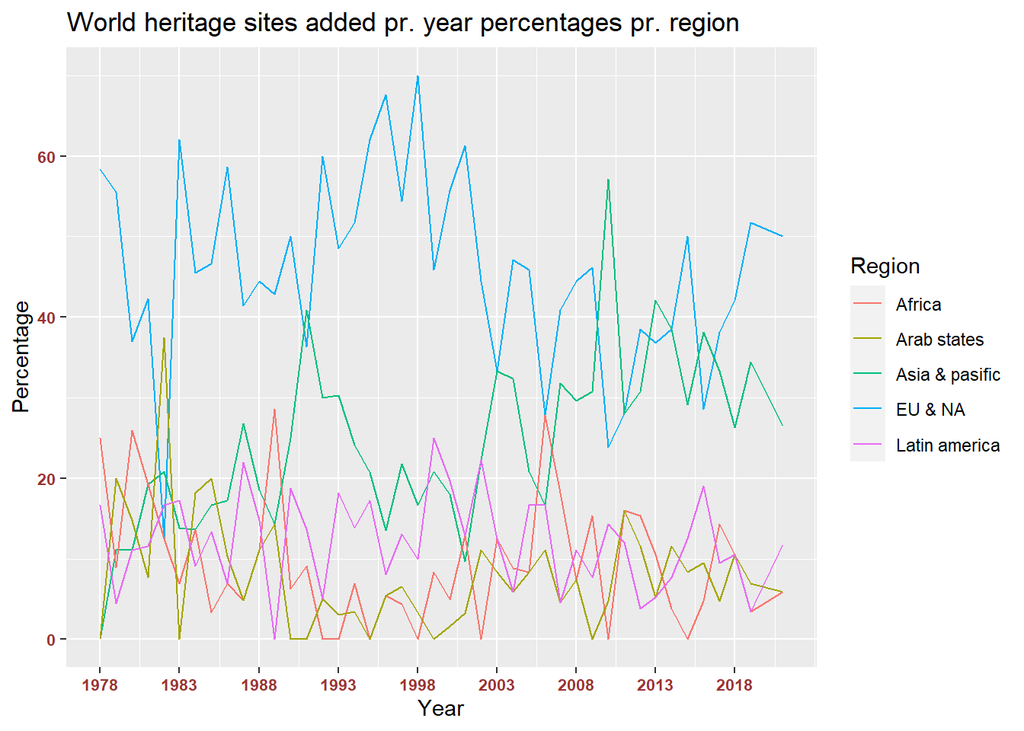

```r
ggplot(Heritage_list_graph_data2, aes(x=year)) +
  geom_line(aes(y=procentage_year_Eu, color="EU & NA")) +
  geom_line(aes(y=procentage_year_AsP, color="Asia & pasific")) +
  geom_line(aes(y=procentage_year_AF, color="Africa"))+
  geom_line(aes(y=procentage_year_AS, color="Arab states")) +
  geom_line(aes(y=procentage_year_LA, color="Latin america"))+
  labs(title="World heritage sites added pr. year percentages pr. region",
       y="Percentage",x="Year",color="Region")+
  scale_x_continuous(breaks = seq(1978,2021,5))+
  theme(axis.text.x = element_text(face="bold", color="#993333",
                                   size=8, angle=0),
        axis.text.y = element_text(face="bold", color="#993333",
                                   size=8, angle=0))
```

## Let’s see the world heritage sites by percentage

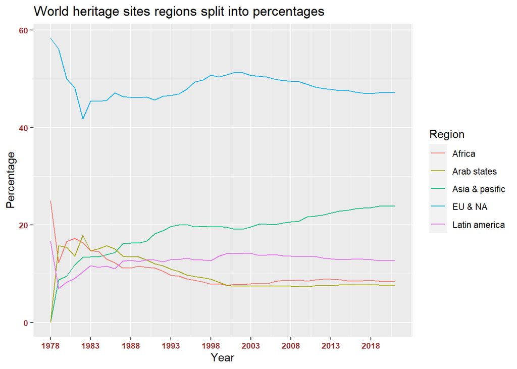

```r
ggplot(Heritage_list_graph_data2, aes(x=year)) +
  geom_line(aes(y=Eu_percentage_cumulative , color="EU & NA")) +
  geom_line(aes(y=AsP_percentage_cumulative , color="Asia & pasific")) +
  geom_line(aes(y=AF_percentage_cumulative , color="Africa"))+
  geom_line(aes(y=AS_percentage_cumulative , color="Arab states")) +
  geom_line(aes(y=LA_percentage_cumulative , color="Latin america"))+
  labs(title="World heritage sites regions split into percentages",
       y="Percentage",x="Year",color="Region")+
  scale_x_continuous(breaks = seq(1978,2021,5))+
  theme(axis.text.x = element_text(face="bold", color="#993333",
                                   size=8, angle=0),
        axis.text.y = element_text(face="bold", color="#993333",
                                   size=8, angle=0))
```

Load in the GDP data

```r
GDP_IMF <- read_excel("data/GDP_DATA.xlsx")
```

```r
head(GDP_IMF)
```

```
## # A tibble: 6 × 230
##    year GDP, cu…¹ Afgha…² Albania Algeria Andorra Angola Antig…³ Argen…⁴ Armenia
##   <dbl> <lgl>     <chr>     <dbl>   <dbl> <chr>    <dbl>   <dbl>   <dbl> <chr>
## 1  1980 NA        no data    1.95    42.3 no data   6.64   0.131   234.  no data
## 2  1981 NA        no data    2.23    44.4 no data   6.21   0.148   190.  no data
## 3  1982 NA        no data    2.30    44.8 no data   6.21   0.164    94.2 no data
## 4  1983 NA        no data    2.32    47.5 no data   6.48   0.182   116.  no data
## 5  1984 NA        no data    2.29    51.5 no data   6.86   0.208   131.  no data
## 6  1985 NA        no data    2.34    61.1 no data   8.46   0.241    98.6 no data
## # … with 220 more variables: Aruba <chr>, Australia <dbl>, Austria <dbl>,
## #   Azerbaijan <chr>, `Bahamas, The` <dbl>, Bahrain <dbl>, Bangladesh <dbl>,
## #   Barbados <dbl>, Belarus <chr>, Belgium <dbl>, Belize <dbl>, Benin <dbl>,
## #   Bhutan <dbl>, Bolivia <dbl>, `Bosnia and Herzegovina` <chr>,
## #   Botswana <dbl>, Brazil <dbl>, `Brunei Darussalam` <chr>, Bulgaria <dbl>,
## #   `Burkina Faso` <dbl>, Burundi <dbl>, `Cabo Verde` <dbl>, Cambodia <chr>,
## #   Cameroon <dbl>, Canada <dbl>, `Central African Republic` <dbl>, …
```

## spreadsheet manipulation

To make this as comparable to the Unesco heritage sites data as possible i want to add a column with Europe and North america as isnt in the data set. the other regions have a column that despite not being a perfect match will suffice for the comparison in this proof of concept

```r
GDP_IMF_Regions <- GDP_IMF %>%
mutate(EU_NA=GDP_IMF$Europe+GDP_IMF$North_America)
```

```r
head(GDP_IMF_Regions) %>%
  select(year,
         EU_NA,
         Asia_and_Pacific,
         Africa_Region,
         Middle_East_Region,
         Latin_America_and_the_Caribbean,
         World)
```

```
## # A tibble: 6 × 7
##    year EU_NA Asia_and_Pacific Africa_Region Middle_East_Region Latin_A…¹  World
##   <dbl> <dbl>            <dbl>         <dbl>              <dbl>     <dbl>  <dbl>
## 1  1980 7384.            2361.          466.               393.      864. 11238.
## 2  1981 7431.            2524.          476.               428.      933. 11498.
## 3  1982 7381.            2456.          482.               416.      766. 11287.
## 4  1983 7570.            2609.          463.               423.      697. 11589.
## 5  1984 7888.            2767.          405.               420.      726. 12002.
## 6  1985 8328.            2821.          397.               422.      779. 12531.
## # … with abbreviated variable name ¹Latin_America_and_the_Caribbean
```

## GDP By region

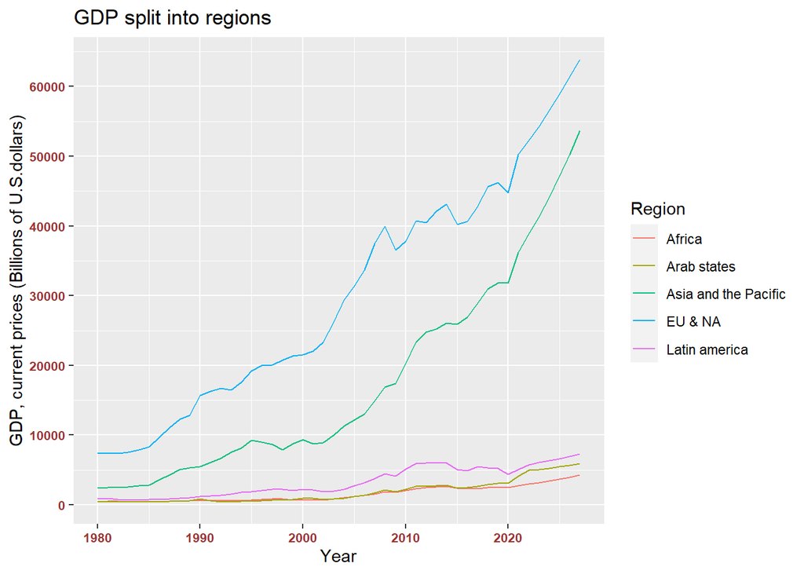

```r
ggplot(GDP_IMF_Regions, aes(x=year)) +
  geom_line(aes(y=EU_NA, color="EU & NA")) +
  geom_line(aes(y=Asia_and_Pacific, color="Asia and the Pacific")) +
  geom_line(aes(y=Africa_Region, color="Africa")) +
  geom_line(aes(y=Middle_East_Region, color="Arab states")) +
  geom_line(aes(y=Latin_America_and_the_Caribbean, color="Latin america")) +
  labs(title="GDP split into regions",
       y="GDP, current prices (Billions of U.S.dollars)",x="Year",color="Region")+
  scale_y_continuous(breaks = seq(0,100000,10000))+
  theme(axis.text.x = element_text(face="bold", color="#993333",
                                   size=8, angle=0),
        axis.text.y = element_text(face="bold", color="#993333",
                                   size=8, angle=0))
```

##adding column to the spreadsheet As my graphs with the Unesco heritage sites in displayed in percentages i want to add percentages columns to the GDP data set

```r
GDP_IMF_Regions_percentages <- GDP_IMF_Regions %>%
mutate(EU_NA_procent=GDP_IMF_Regions$EU_NA/GDP_IMF_Regions$World*100) %>%
mutate(La_procent=GDP_IMF_Regions$Latin_America_and_the_Caribbean/GDP_IMF_Regions$World*100) %>%
mutate(Arab_procent=GDP_IMF_Regions$Middle_East_Region/GDP_IMF_Regions$World*100) %>%
mutate(Asia_Pacific_procent=GDP_IMF_Regions$Asia_and_Pacific/GDP_IMF_Regions$World*100) %>%
mutate(Africa_procent=GDP_IMF_Regions$Africa_Region/GDP_IMF_Regions$World*100)
```

```r
head(GDP_IMF_Regions_percentages) %>%
   select(year,
         EU_NA_procent,
         La_procent,
         Arab_procent,
         Asia_Pacific_procent,
         Africa_procent,
         EU_NA,
         Asia_and_Pacific,
         Africa_Region,
         Middle_East_Region,
         Latin_America_and_the_Caribbean,
         World)
```

```
## # A tibble: 6 × 12
##    year EU_NA_pr…¹ La_pr…² Arab_…³ Asia_…⁴ Afric…⁵ EU_NA Asia_…⁶ Afric…⁷ Middl…⁸
##   <dbl>      <dbl>   <dbl>   <dbl>   <dbl>   <dbl> <dbl>   <dbl>   <dbl>   <dbl>
## 1  1980       65.7    7.68    3.50    21.0    4.15 7384.   2361.    466.    393.
## 2  1981       64.6    8.12    3.72    22.0    4.14 7431.   2524.    476.    428.
## 3  1982       65.4    6.78    3.68    21.8    4.27 7381.   2456.    482.    416.
## 4  1983       65.3    6.01    3.65    22.5    3.99 7570.   2609.    463.    423.
## 5  1984       65.7    6.05    3.50    23.1    3.37 7888.   2767.    405.    420.
## 6  1985       66.5    6.22    3.37    22.5    3.17 8328.   2821.    397.    422.
## # … with 2 more variables: Latin_America_and_the_Caribbean <dbl>, World <dbl>,
## #   and abbreviated variable names ¹EU_NA_procent, ²La_procent, ³Arab_procent,
## #   ⁴Asia_Pacific_procent, ⁵Africa_procent, ⁶Asia_and_Pacific, ⁷Africa_Region,
## #   ⁸Middle_East_Region
```

## plotting the newly added columns

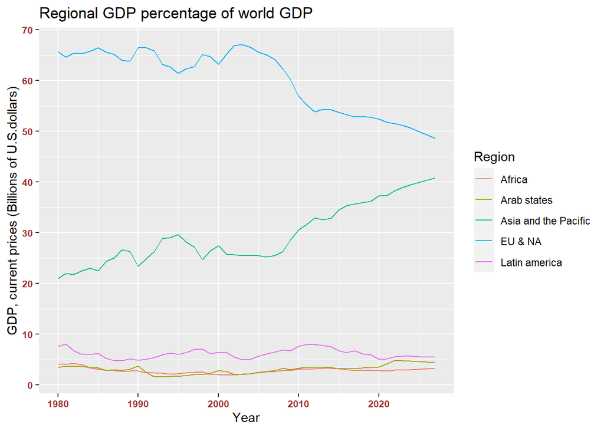

```r
ggplot(GDP_IMF_Regions_percentages, aes(x=year)) +
  geom_line(aes(y=EU_NA_procent, color="EU & NA")) +
  geom_line(aes(y=Asia_Pacific_procent, color="Asia and the Pacific")) +
  geom_line(aes(y=Africa_procent, color="Africa")) +
  geom_line(aes(y=Arab_procent, color="Arab states")) +
  geom_line(aes(y=La_procent, color="Latin america")) +
  labs(title="Regional GDP percentage of world GDP",
       y="GDP, current prices (Billions of U.S.dollars)",x="Year",color="Region")+
  scale_y_continuous(breaks = seq(0,100,10))+
  theme(axis.text.x = element_text(face="bold", color="#993333",
                                   size=8, angle=0),
        axis.text.y = element_text(face="bold", color="#993333",
                                   size=8, angle=0))
```

## plotting the five comparison graphs

Now i want to combine the percentages graphs with the GDP and the percentages graphs of unesco heritages sites to see wether or not there is a correlation between GDP and unesco heritage sites.

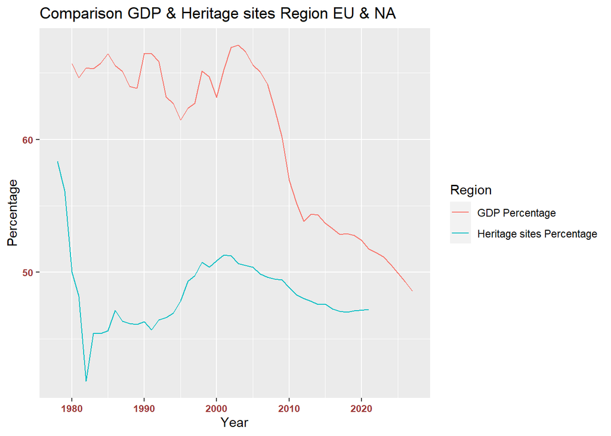

```r
ggplot() +
  geom_line(aes(x=GDP_IMF_Regions_percentages$year,
                y=GDP_IMF_Regions_percentages$EU_NA_procent,
                color="GDP Percentage"))+
   geom_line(aes(x=Heritage_list_graph_data2$year,
                y=Heritage_list_graph_data2$Eu_percentage_cumulative,
                color="Heritage sites Percentage"))+
  labs(title="Comparison GDP & Heritage sites Region EU & NA",
       y="Percentage",x="Year",color="Region")+
  scale_y_continuous(breaks = seq(0,100,10))+
  theme(axis.text.x = element_text(face="bold", color="#993333",
                                   size=8, angle=0),
        axis.text.y = element_text(face="bold", color="#993333",
                                   size=8, angle=0))
```

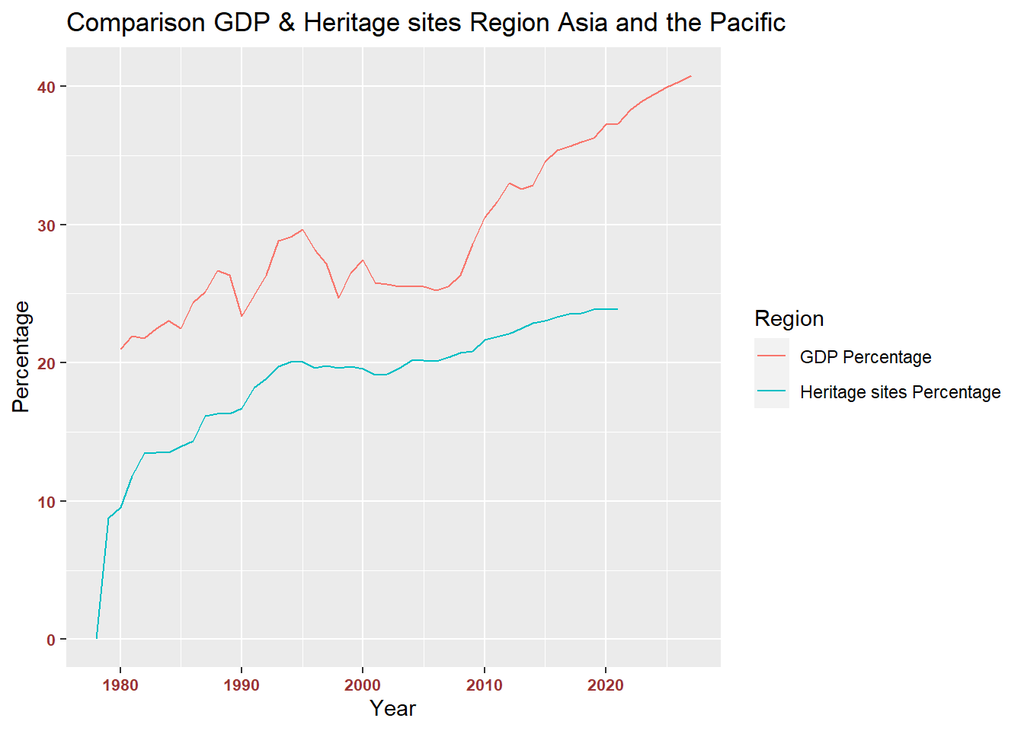

```r
ggplot() +
  geom_line(aes(x=GDP_IMF_Regions_percentages$year,
                y=GDP_IMF_Regions_percentages$Asia_Pacific_procent,
                color="GDP Percentage"))+
   geom_line(aes(x=Heritage_list_graph_data2$year,
                y=Heritage_list_graph_data2$AsP_percentage_cumulative,
                color="Heritage sites Percentage"))+
  labs(title="Comparison GDP & Heritage sites Region Asia and the Pacific",
       y="Percentage",x="Year",color="Region")+
  scale_y_continuous(breaks = seq(0,100,10))+
  theme(axis.text.x = element_text(face="bold", color="#993333",
                                   size=8, angle=0),
        axis.text.y = element_text(face="bold", color="#993333",
                                   size=8, angle=0))
```

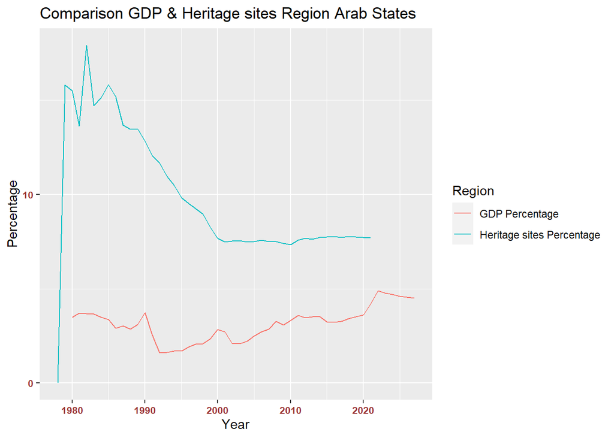

```r
ggplot() +
  geom_line(aes(x=GDP_IMF_Regions_percentages$year,
                y=GDP_IMF_Regions_percentages$Arab_procent,
                color="GDP Percentage"))+
   geom_line(aes(x=Heritage_list_graph_data2$year,
                y=Heritage_list_graph_data2$AS_percentage_cumulative,
                color="Heritage sites Percentage"))+
  labs(title="Comparison GDP & Heritage sites Region Arab States",
       y="Percentage",x="Year",color="Region")+
  scale_y_continuous(breaks = seq(0,100,10))+
  theme(axis.text.x = element_text(face="bold", color="#993333",
                                   size=8, angle=0),
        axis.text.y = element_text(face="bold", color="#993333",
                                   size=8, angle=0))
```

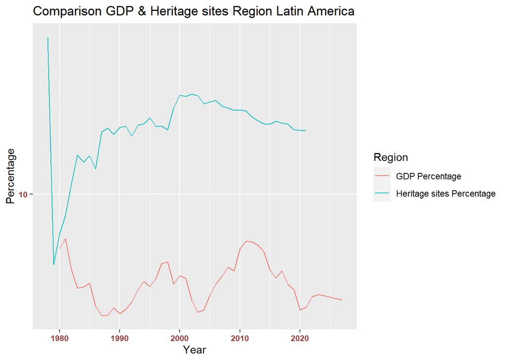

```r
ggplot() +
  geom_line(aes(x=GDP_IMF_Regions_percentages$year,
                y=GDP_IMF_Regions_percentages$La_procent,
                color="GDP Percentage"))+
   geom_line(aes(x=Heritage_list_graph_data2$year,
                y=Heritage_list_graph_data2$LA_percentage_cumulative,
                color="Heritage sites Percentage"))+
  labs(title="Comparison GDP & Heritage sites Region Latin America",
       y="Percentage",x="Year",color="Region")+
  scale_y_continuous(breaks = seq(0,100,10))+
  theme(axis.text.x = element_text(face="bold", color="#993333",
                                   size=8, angle=0),
        axis.text.y = element_text(face="bold", color="#993333",
                                   size=8, angle=0))
```

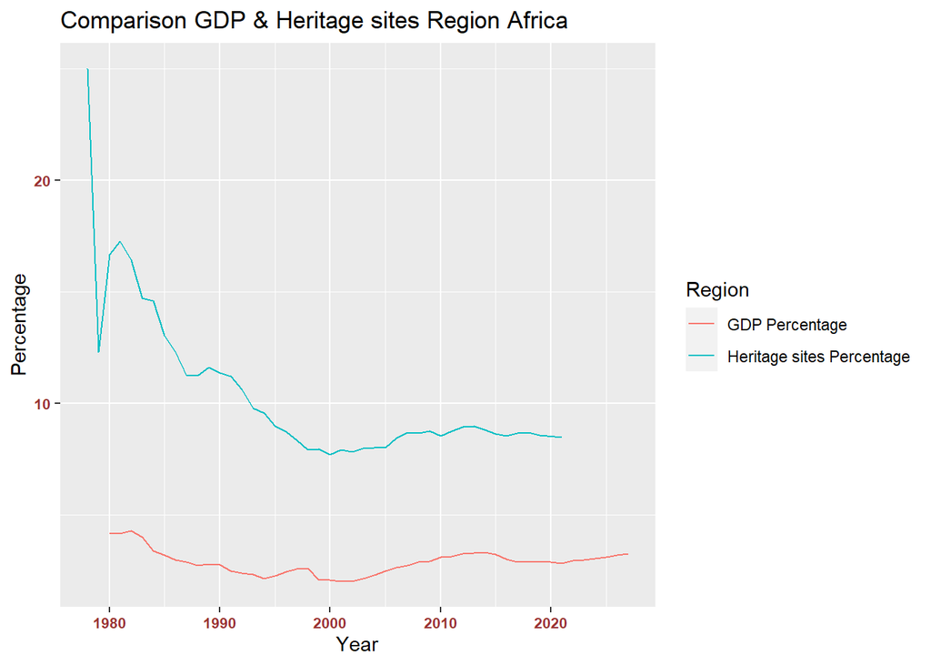

```r
ggplot() +
  geom_line(aes(x=GDP_IMF_Regions_percentages$year,
                y=GDP_IMF_Regions_percentages$Africa_procent,
                color="GDP Percentage"))+
   geom_line(aes(x=Heritage_list_graph_data2$year,
                y=Heritage_list_graph_data2$AF_percentage_cumulative,
                color="Heritage sites Percentage"))+
  labs(title="Comparison GDP & Heritage sites Region Africa",
       y="Percentage",x="Year",color="Region")+
  scale_y_continuous(breaks = seq(0,100,10))+
  theme(axis.text.x = element_text(face="bold", color="#993333",
                                   size=8, angle=0),
        axis.text.y = element_text(face="bold", color="#993333",
                                   size=8, angle=0))
```

## mini conclusion

Looking at the graphs there doesnt seem to be a consistent trend between world heritage sites and GDP. Whilst this isnt a conclusive analysis, it goes to show that the cause for the westerns worlds heavy precense on the list isnt directly linked to GDP